# My Shiny Story

### Security

A pressing security issue is concatenating user input with the query string. As a rule of thumb, never mix trusted data (in this case, the query string) with untrusted data (the user input). If a user passed a string for the input, then they could execute arbitrary commands against the database. Put another way; the app is vulnerable to injection attacks. We can reduce the risk of injection attacks by sanitizing our inputs. The sqlinterpolate function from DBI helps with this. It escapes single ticks and binds inputs to the parameters.

```r
myquery <- "EXECUTE dbo.getCPUutilization ?cpu_slider_param"

myquery_param <- sqlInterpolate(con,myquery,.dots =c(cpu_slider_param <- input$cpu_slider))

mydata <- dbGetQuery(con,myquery_param)
```

It might make sense to use white lists certain inputs. For example, check that an email input field follows a specified pattern. The code below populates emailistwhitelist with a regex pattern of a valid email. The if() function checks if the input matches the pattern. If it doesn’t match, then query won’t touch the database.

```r
emailwhitelist <- "^[[:alnum:].-_]+@[[:alnum:].-]+$"

if(!is.na(str_match(usr_email, emailwhitelist))){
  #Run query
} else
{
  # Reject input
}
```

### Connection Management

The app seems a little sluggish. If performance isn’t acceptable, then the first place to turn is profvis. Profvis provides line by line execution metrics for R code. The profvis function launches the app. Then we interact with the application as an average user would. When the browser closes, profvis generates a report with a .Rprofvis extension. The report shows memory consumed and execution time for each function. Also, a flame graph shows execution time at each stage of the call stack.

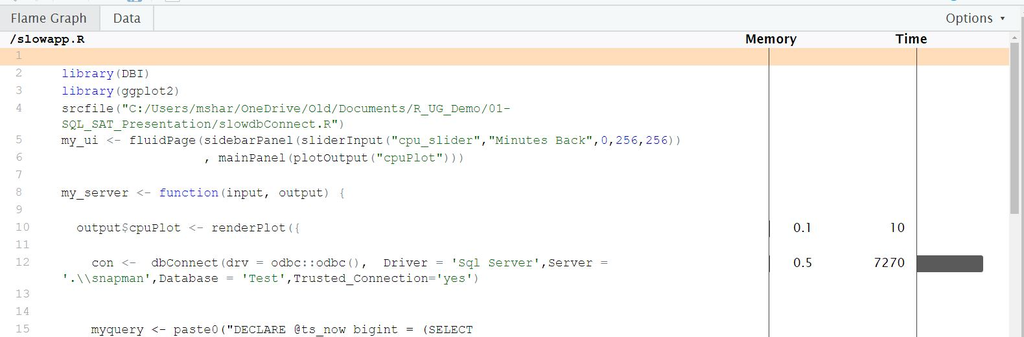

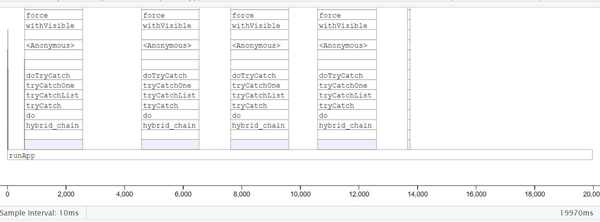

The profile session reveals dbConnect() accounts for most of the execution time. The app makes a connection to our database each time the user adjusts the slider input. Instead of opening and closing a connection for each query we could grab an open connection from a pool. The pool library allows us to use pooling with a few code changes. First we replace the dbConnect() with dbPool(). We don’t need to close the pool when the application is running so dbDisconnect() gets removed. Finally, we move dbPool() outside of the server object completely.

```r
library(pool)
pool <- dbPool(drv = odbc(),Driver = mydriver,Server = myserver,Database = myDatabase)
  results <- dbGetQuery(pool,myquery)
```

Besides making our session faster, pool also helps the app scale. Pool opens and closes connections as needed without developer intervention. So as the workload start to increase more open connection become available.

### Error Handling

Error handling can improve user experience and prevent the app from crashing. If an error occurs, the app should do something like alert the user. When we increase app complexity, we increase the need for error handling. Adding a relational database to the app is an example of increasing complexity. It’s a good idea to build redundancy around the database connection. How would the app respond if the database server went down? How would the app respond if there was a deadlock? I’ll simulate a database outage by forcing the database offline while the app is running.

```sql
ALTER Database Test Set SINGLE_USER WITH ROLLBACK IMMEDIATE;
ALTER Database Test Set OFFLINE;
```

When the user adjusts the slider, the query attempts to re-run but fails. R displays an error containing the query text where the plot should be. This error is not helpful to the average user. Also, the app shouldn’t expose implementation details like table names to end-users.

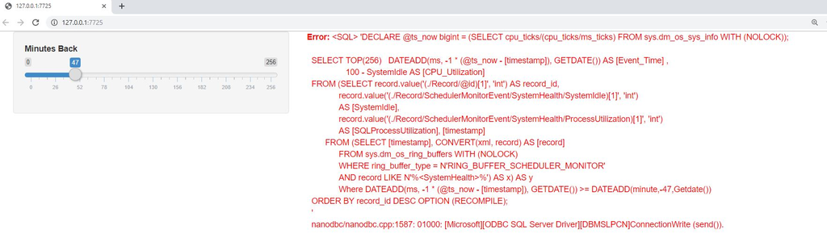

We can avoid this issue with a tryCatch function wrapped around the query execution. If an error occurs, code in the error function executes.

```r
      tryCatch({
        results <- dbGetQuery(pool,myquery)
        j<- ggplot(results,aes(Event_Time,CPU_Utilization))
        j+ geom_line()
        },error =function(e) {
            showModal(modalDialog(
                h5('There was an error.  Please contact the system admin.')
            )
            )
        })
```

Now instead of red error messages, the user gets a modal box with instructions.

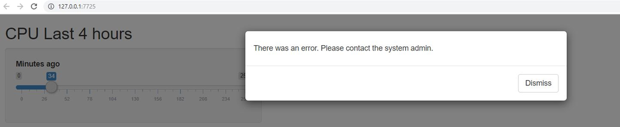

The error function stores error details from the R session like the error message. It’s possible to write error specific messages or events. For example, we could retry the query if the text contains “1205” in the error text. SQL server throws 1205 errors when it detects deadlocks. R retries three times before giving up.

```r
tryCatch({
    dbGetQuery(con,myquery)
}
,error = function(e){
  if(grep('1205',e$message)==1){
    while (x<4){
      tryCatch({
        dbGetQuery(con,myquery)
        break
        }
      ,error=function(e){
      x<<- x+1
      })
    }
  }
})
```

### Load Testing

The app has reached acceptable performance for one user session. But how does the app handle concurrent user sessions? We can find out using a load test. Load tests depend on the shinyload package, the shinycannon program, and Java.

The first step of a load test is recording a typical user session. I record the session with the app hosted on my local machine. I start two instances of Rstudio. One runs the Shiny app, and the other runs the recording function record_session().

```r
shinyloadtest::record_session('http://127.0.0.1:6696/')
```

The record_session function launches the app in a browser. Once the browser closes, Shinycannon writes the session actions to recording.log. Shinycannon replays recording.log for as long and in as many user sessions specified. The second required argument is the app URL. We’ll see how the app performs with 50 users for two minutes of load. The following code runs in a terminal.

```bash
$ shinycannon recording.log http://127.0.0.1:6696/ --workers 50 --loaded-duration-minutes 2
```

After the load test finishes, we can view the results through shinyloadtest.

```r
df <- shinyloadtest::load_runs("50workers" = "./test-logs-2019-07-22T03_21_19.997Z")

shinyloadtest::shinyloadtest_report(df, "run1.html")
```

[figure not shown]

The X-Axis represents elapsed time, and the Y-axis represents displays each session. The black dots show the app under full load. Full load in this specific test means 50 concurrent users. At ten concurrent users, session performance plummets. The 11th app user would be waiting seconds for plots to render. Interrupting workflow for this long makes for unhappy users. We need a go-faster button.

### Caching

We know that two of the most expensive function were renderPlot and dbGetQuery. We can’t tune the query much, but we can remove the OPTION(recompile) query hint. Removing the hint enables plan caching on the SQL server. Instead of recompiling the plan each time our app looks it up in cache.

```r
--OPTION (RECOMPILE);"## Disabling hint so plan caching can occur
```

We can also enable plot caching with minor app code changes. First, the renderCachedPlot function replaces renderPlot. Second, we specify a cache key after the renderCachedPlot closing curly brace. The natural choice is the input slider. When a user selects the same input, they, in theory, would be requesting the same plot. Rather than re-render the same plot, the app can retrieve it from cache.

```r
  },cacheKeyExpr = {input$cpu_slider})
```

Before we re-run the load test, I must point out that our app would not work with caching in its current state. The query returns a sliding window and is not deterministic. Say, for example, I submit a query with a slider input value of 256. Then five minutes later, I submit the same query. The data would change, but if we pulled the plot from cache, it would reflect stale data. We could persist the results of the query in a table and update the input control to a timestamp or numeric field. This change makes the app compatible with plot caching. For the demo, we not add the change as the focus is on performance implications. With plot caching, the load test reveals a significant performance enhancement.

[figure not shown]

Each event now executes in milliseconds, which improves concurrency. The 50th user has a similar experience with the app as the first. It’s a safe assumption the app can scale beyond 50 users. Here’s the completed app.

```r
library(DBI)
library(ggplot2)
library(pool)

tryCatch({
con <-  dbPool(drv = odbc::odbc(),
               Driver = 'Sql Server',Server = '.\\snapman',Database = 'Test')
},error = function(e){showModal(modalDialog('Connection Error'))})

my_ui <- fluidPage(sidebarPanel(sliderInput("cpu_slider","Minutes Back",0,256,256))
                   , mainPanel(plotOutput("cpuPlot")))

my_server <- function(input, output) {
  output$cpuPlot <- renderCachedPlot({
    myquery <- paste0("Execute dbo.getCPUutilization ?minRange")
    myqueryint <- sqlInterpolate(con,myquery,.dots=c(minRange=input$cpu_slider))
    tryCatch({
      mydata <- dbGetQuery(con,myqueryint)
      ggplot(mydata,aes(Event_Time,CPU_Utilization)) + geom_line()},
      error = function(e){
        showModal(modalDialog('There was an error.'))
      }
    )
  },cacheKeyExpr = input$cpu_slider)
}
shinyApp(ui = my_ui, server = my_server)
```

### Summary

I had a tough problem at my last job. I took responsibility for a web-app written in a unfamiliar stack. I re-wrote the app using the R package Shiny which helped simplify the development process. I had concerns about scale and functionality. However, I learned with proper design, a Shiny app can serve 50 users easily. I used R functions for improving security, connection management, error handling, and caching.

I ended up using Shiny for several other Data Science projects. Each project had unique requirements and challenges. And each time R had an answer. If a Data Science team needs to write a self-service web-app then R is a good choice.